# ps1-sf-qaa

Kosiso Onwuzu

10/5/2017

**Bi624 – Problem Set 1 - SF-Seq Quality Assessment Assignment**

The objectives of this assignment are to use existing tools for quality assessment and adaptor trimming, compare the quality assessments to those from your own software, and demonstrate your ability to summarize other important information about this RNA-Seq data set.

**Data**

Each of you will be working with 2 of the demultiplexed file pairs. For all steps below, process the two libraries separately. Library assignments are here: /projects/bgmp/Bi624/PS1_file_assignments.tsv

```
  My pairs: 17_3E_fox       24_4A_control
```

The demultiplexed .fastq files are here: /projects/bgmp/2017_sequencing/demultiplexed/

**Part 1 – SF-Seq read quality score distributions**

Using FastQC on Talapas, produce plots of quality score distributions for forward and reverse reads. Also, produce plots of the per-base N content, and comment on whether or not they are consistent with the quality score plots.

FatstQC srun script:

```
#!/usr/bin/env bash

#SBATCH --partition=long
#SBATCH --job-name=fqc
#SBATCH --output=fqc.out
#SBATCH --error=fqc.err
#SBATCH --time=0-23:01:00
#SBATCH --nodes=1
#SBATCH --ntasks-per-node=28


ml easybuild intel/2017a FastQC

fastqc 17_3E_fox_S13_L008_R1_001.fastq.gz 17_3E_fox_S13_L008_R2_001.fastq.gz 24_4A_control_S18_L008_R1_001.fastq.gz 24_4A_control_S18_L008_R2_001.fastq.gz
```

*Output files sent separately

Run your quality score plotting script from the index hopping assignment.

My quality score plotting script:

```
#!/usr/bin/env python


###qscore script to generate per base call distribution of quality scores for illumina fastq files.
###script also averages the Quality scores for each read.


import argparse

# Usage:
    # ps5script.py -f seq.fq
    # ps5script.py --file seq.fq


def get_arguments():
    parser = argparse.ArgumentParser(description="generate per base call distribution of quality scores")
    parser.add_argument("-i", "--infile", help="fastq file", required=True, type=str)
    return parser.parse_args()

args = get_arguments()

print(args.infile)
infile = args.infile

##import numpy as np


qscorearray = [0]*101
qlinearray = []

def convert_phred(letter):
    '''converts letter to phred score'''
    #ord() returns an integer representing the Unicode code point of the letter
    q = ord(letter)
    q = q - 33
    return q

with open(infile, 'r') as fh:
#with open("/home/konwuzu/indx/r2test", 'r') as fh:
    ##initialization for line read increments
```

[output cut: 43 more lines]

```
    a = 0
    #initializing w 1 for base position, a =0 bc of python 0 indexing
    c = 1
    for val in qscorearray:
        out1.write(str(c)+ "\t" + str(qscorearray[a]) + "\n")
        a += 1
        c += 1

#mean of each read file
with open("mean_q_line_"+infile, "w") as out2:
    out2.write("Mean of qline" + "\n")
    b = 0
    for val in qlinearray:
        out2.write(str(qlinearray[b]) + "\n")
        b += 1
```

*gunzipped files for script

Output files copied to local directory: `scp konwuzu@talapas-login.uoregon.edu:/home/konwuzu/bi624/ps1/mean_q_bp_24_4A_control_S18_L008_R1_001.fastq konwuzu@talapas-login.uoregon.edu:/home/konwuzu/bi624/ps1/mean_q_bp_24_4A_control_S18_L008_R2_001.fastq .`

`scp konwuzu@talapas-login.uoregon.edu:/home/konwuzu/bi624/ps1/mean_q_bp_17_3E_fox_S13_L008_R1_001.fastq konwuzu@talapas-login.uoregon.edu:/home/konwuzu/bi624/ps1/mean_q_bp_17_3E_fox_S13_L008_R2_001.fastq .`

Output of my qscore script (mean of each position file) plotted below:

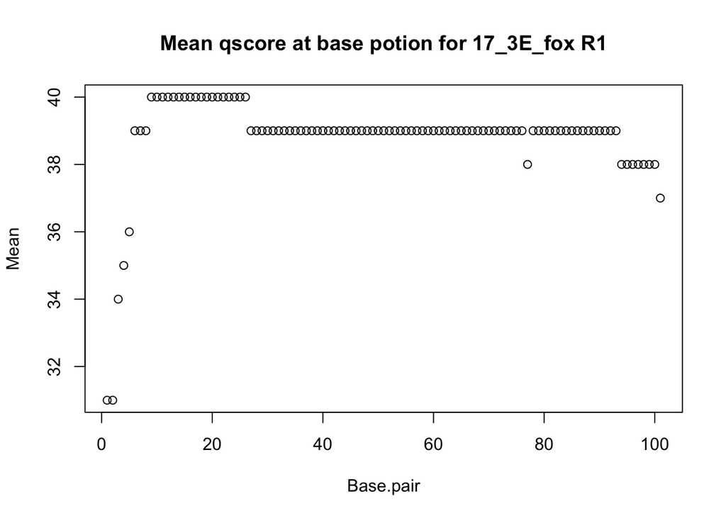

```r
foxr1_mean_q_bp <- read.delim("mean_q_bp_17_3E_fox_S13_L008_R1_001.fastq")
plot(foxr1_mean_q_bp, main = "Mean qscore at base potion for 17_3E_fox R1")
```

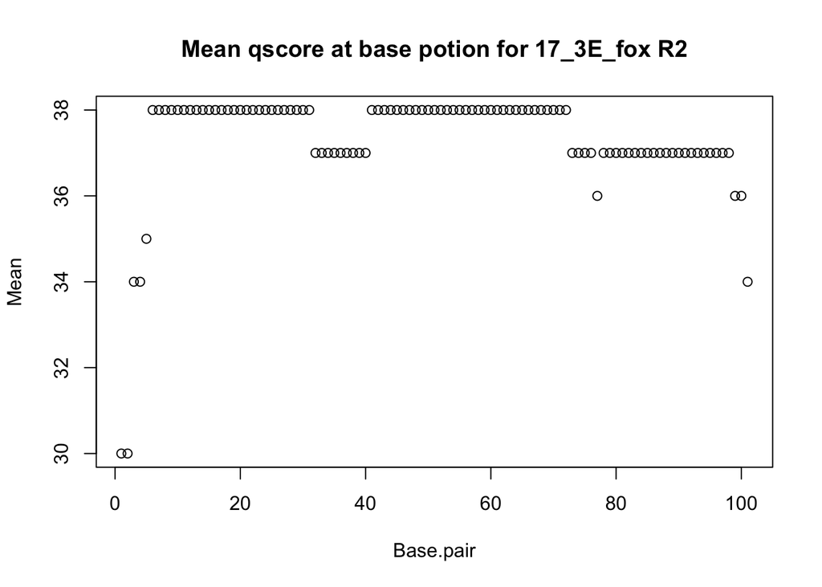

```r
foxr2_mean_q_bp <- read.delim("mean_q_bp_17_3E_fox_S13_L008_R2_001.fastq")
plot(foxr2_mean_q_bp, main = "Mean qscore at base potion for 17_3E_fox R2")
```

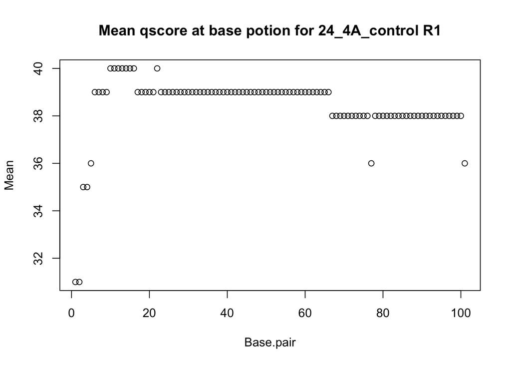

```r
ctrlr1_mean_q_bp <- read.delim("mean_q_bp_24_4A_control_S18_L008_R1_001.fastq")
plot(ctrlr1_mean_q_bp, main = "Mean qscore at base potion for 24_4A_control R1")

ctrlr2_mean_q_line <- read.delim("mean_q_bp_24_4A_control_S18_L008_R2_001.fastq")
plot(ctrlr1_mean_q_bp, main = "Mean qscore at base potion for 24_4A_control R1")
```

[output not shown]

Describe how the FastQC quality score distribution plots compare to your own. If different, propose an explanation. Also, does the runtime differ? If so, why?

The fastqc-produced plots of the files are very similiar to those produced by my quality score script `ps1-qscore-script.py`. The fastqc plots is however more detailed in that it displays the standard deviation bar for each qscore at each base pair position. The runtime for the fastqc was however faster, with a runtime of about 6 mins (time elapsed gotten with command `sacct -l -j 157382 | less -S` output = `elapsed = 06:17s`. The fastqc java script must have utilized better computational data structures than my python script.

**Part 2 – Adaptor trimming comparison**

Look into the adaptor trimming options for cutadapt, process_shortreads, and Trimmomatic (all on Talapas), and briefly describe the differences.

Cutadapt: N-tolerant and written in python. It also processes gzipped files without a flag.

Process_shortreads: can exclude reads with low quality scores or uncalled bases and collects orphaned reads separately. Process_shortreads also requires that you specify gzipped files with a flag.

Trimmomatic (unlike cutadapt and process_shortreads) takes the adapter sequences in a fasta file and not as with a flag. It is also written in Java.

Pick one of these to properly trim adapter sequences. Use default settings.

Process_shortreads srun script:

17_3E_fox

```
#!/usr/bin/env bash

#SBATCH --partition=short
#SBATCH --job-name=shortreads
#SBATCH --output=sbatchstacks.out
#SBATCH --error=sbatchstacks.err
#SBATCH --time=0-23:01:00
#SBATCH --nodes=1
#SBATCH --ntasks-per-node=28


ml purge
ml slurm easybuild intel/2017a Stacks/1.46

process_shortreads -1 /home/konwuzu/bi624/ps1/17_3E_fox_S13_L008_R1_001.fastq.gz -2 /home/konwuzu/bi624/ps1/17_3E_fox_S13_L008_R2_001.fastq.gz -i gzfastq -o /home/konwuzu/bi624/ps1/shortreadsout  --adapter_1 AGATCGGAAGAGCACACGTCTGAACTCCAGTCAC --adapter_2 AGATCGGAAGAGCGTCGTGTAGGGAAAGAGTGT
```

24_4A_control

```
#!/usr/bin/env bash

#SBATCH --partition=short
#SBATCH --job-name=srctrl
#SBATCH --output=srctrl.out
#SBATCH --error=srctrl.err
#SBATCH --time=0-23:01:00
#SBATCH --nodes=1
#SBATCH --ntasks-per-node=28


ml purge
ml slurm easybuild intel/2017a Stacks/1.46

process_shortreads -1 /home/konwuzu/bi624/ps1/24_4A_control_S18_L008_R1_001.fastq.gz -2 /home/konwuzu/bi624/ps1/24_4A_control_S18_L008_R2_001.fastq.gz -i gzfastq -o /home/konwuzu/bi624/ps1/srctrl2  --adapter_1 AGATCGGAAGAGCACACGTCTGAACTCCAGTCAC --adapter_2 AGATCGGAAGAGCGTCGTGTAGGGAAAGAGTGT
```

What proportion of reads (both forward and reverse) was trimmed?

```
    The process_shortreads.log file shows that 1356715 of the 17_3E_fox were trimmed.
    Proportion = 1356715/23568820 = 0.0575 or 5.8%

    The processshortreads.log file shows that 228960 of the 24_4A_control were trimmed.
    Proportion = 228960/21031748 = 0.0108 or 1.1%
```

Sanity check: Use your Unix skills to search for the adapter sequences in your datasets and confirm the expected sequence orientations.

```
zcat 17_3E_fox_S13_L008_R1_001.fastq.gz | grep -A1 "^@K00" --no-group-separator | grep -v "^@K00" | grep "AGATCGGAAGAGCACACGTCTGAACTCCAGTCAC" | wc -l
121769

zcat 17_3E_fox_S13_L008_R2_001.fastq.gz | grep -A1 "^@K00" --no-group-separator | grep -v "^@K00" | grep "AGATCGGAAGAGCGTCGTGTAGGGAAAGAGTGT" | wc -l
133008

zcat 24_4A_control_S18_L008_R1_001.fastq.gz | grep -A1 "^@K00" --no-group-separator | grep -v "^@K00" | grep "AGATCGGAAGAGCACACGTCTGAACTCCAGTCAC" | wc -l
7417

zcat 24_4A_control_S18_L008_R2_001.fastq.gz | grep -A1 "^@K00" --no-group-separator | grep -v "^@K00" | grep "AGATCGGAAGAGCGTCGTGTAGGGAAAGAGTGT" | wc -l
8484
```

*adapter sequences were gotten from bi623 Assignment 5 (Block 1). Fastqc output also showed adapters to be likely Illumina Universal Adapters.

Plot the trimmed read length distributions for both forward and reverse reads (on the same plot). If necessary, consult Assignment 5 (Block 1) from Bi 623 to refresh your memory.

To get trimmed distribution:

```
zcat 17_3E_fox_S13_L008_R1_001.1.fq.gz | grep -A1 '^@8_11' --no-group-separator | grep -v '^@8_11' | awk '{print length($0)}' |  sort | uniq -c > foxr1processshortreads
zcat 17_3E_fox_S13_L008_R2_001.2.fq.gz | grep -A1 '^@8_11' --no-group-separator | grep -v '^@8_11' | awk '{print length($0)}' |  sort | uniq -c > foxr2processshortreads


zcat 24_4A_control_S18_L008_R1_001.1.fq.gz | grep -A1 '^@8_11' --no-group-separator | grep -v '^@8_11' | awk '{print length($0)}' |  sort | uniq -c > ctrlr1processshortreads
zcat 24_4A_control_S18_L008_R2_001.2.fq.gz | grep -A1 '^@8_11' --no-group-separator | grep -v '^@8_11' | awk '{print length($0)}' |  sort | uniq -c > ctrlr2processshortreads
```

files copied to local directory: `scp konwuzu@talapas-login.uoregon.edu:/home/konwuzu/bi624/ps1/shortreadsout/foxr1processshortreads konwuzu@talapas-login.uoregon.edu:/home/konwuzu/bi624/ps1/shortreadsout/foxr2processshortreads konwuzu@talapas-login.uoregon.edu:/home/konwuzu/bi624/ps1/srctrl2/ctrlr1processshortreads konwuzu@talapas-login.uoregon.edu:/home/konwuzu/bi624/ps1/srctrl2/ctrlr2processshortreads .`

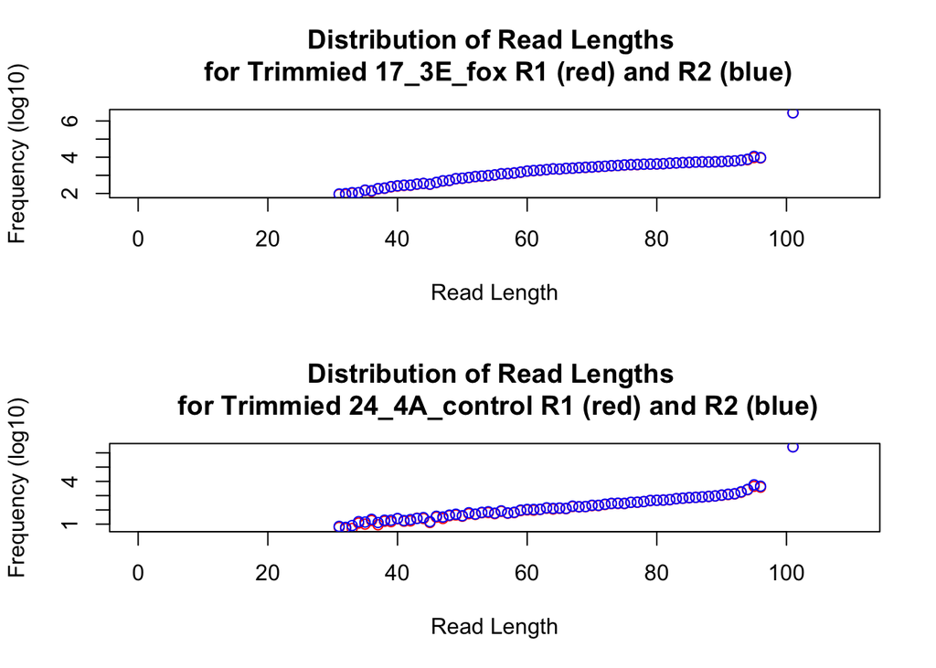

```r
foxr1psr <- read.table("foxr1processshortreads")
foxr2psr <- read.table("foxr2processshortreads")

foxlogr1 <- foxr1psr
foxlogr1[,1] <- log10(foxr1psr[,1])
foxlogr2 <- foxr2psr
foxlogr2[,1] <- log10(foxr2psr[,1])


par(mfrow=c(2,1))

plot(foxlogr1[,2], foxlogr1[,1], ylab = "Frequency (log10)", xlab = "Read Length", xlim=c(0,110), col = "red", type = "p", main = "Distribution of Read Lengths \n for Trimmied 17_3E_fox R1 (red) and R2 (blue)")
points(foxlogr2[,2], foxlogr2[,1], ylab = "Frequency (log10)", xlab = "Read Length", xlim=c(0,110), col = "blue", type = "p", main = "Distribution of Read Lengths \n for Trimmied 17_3E_fox R2")


ctrlr1 <- read.table("ctrlr1processshortreads")
ctrlr2 <- read.table("ctrlr2processshortreads")

ctrllogr1 <- ctrlr1
ctrllogr1[,1] <- log10(ctrlr1[,1])
ctrllogr2 <- ctrlr2
ctrllogr2[,1] <- log10(ctrlr2[,1])


plot(ctrllogr1[,2], ctrllogr1[,1], ylab = "Frequency (log10)", xlab = "Read Length", xlim=c(0,110), col = "red", type = "p", main = "Distribution of Read Lengths \n for Trimmied 24_4A_control R1 (red) and R2 (blue)")
points(ctrllogr2[,2], ctrllogr2[,1], ylab = "Frequency (log10)", xlab = "Read Length", xlim=c(0,110), col = "blue", type = "p", main = "Distribution of Read Lengths \n for Trimmied 24_4A_control R2")
```

Briefly describe whether the adaptor trimming results are consistent with the insert size distributions for your libraries. The size distribution information is in the Fragment Analyzer trace file on Github.

The adapter trimming results are consistent with the insert size distribution of the library. The Fragment Analyzer report shows that the mean insert size of the libraries were ~400bp. With a smaller insert size, we would expect a lot more trimming as sequencing would likely occur past the insert and into the adapters.

**Part 3 – rRNA reads and strand-specificity**

Find publicly available mouse rRNA sequences and generate a gsnap database from them.

From rfam.xfam.org, “FTP” link clicked and in terminal:

```
cp /Volumes/Rfam/13.0/fasta_files/RF00001.fa.gz .
cp /Volumes/Rfam/13.0/fasta_files/RF02541.fa.gz .
cp /Volumes/Rfam/13.0/fasta_files/RF02540.fa.gz .
cp /Volumes/Rfam/13.0/fasta_files/RF01960.fa.gz .
cp /Volumes/Rfam/13.0/fasta_files/RF02543.fa.gz .
cp /Volumes/Rfam/13.0/fasta_files/RF00002.fa.gz .
```

*cp’d into local directory so transfered to hpc directory

Mouse sequences selected and collated by:

```
zcat RF00001.fa.gz | grep -A 1 "Mus musculus" > mus_musculus-rrna.fa
zcat RF00002.fa.gz | grep -A 1 "Mus musculus" >> mus_musculus-rrna.fa
zcat RF01960.fa.gz | grep -A 1 "Mus musculus" >> mus_musculus-rrna.fa
zcat RF02540.fa.gz | grep -A 1 "Mus musculus" >> mus_musculus-rrna.fa
zcat RF02541.fa.gz | grep -A 1 "Mus musculus" >> mus_musculus-rrna.fa
zcat RF02543.fa.gz | grep -A 1 "Mus musculus" >> mus_musculus-rrna.fa
grep -v "^--$" mus_musculus-rrna.fa > mus_musculus_rrna.fa
```

To make gsnap db: `ml easybuild GCC/6.3.0-2.27 OpenMPI/2.0.2 GMAP-GSNAP/2017-06-20` `gmap_build -D /home/konwuzu/bi624/ps1 -d mus_musculus mus_musculus_rrna.fa`

Align the SF-Seq reads to your mouse rRNA database and report the proportion of reads that likely came from rRNAs.

Gsnap srun script:

```
#!/usr/bin/env bash

#SBATCH --partition=long
#SBATCH --job-name=gsnap-ps1
#SBATCH --output=gsnap-ps1.out
#SBATCH --error=gsnap-ps1.err
#SBATCH --time=0-23:01:00
#SBATCH --nodes=1
#SBATCH --ntasks-per-node=28



ml easybuild  GCC/6.3.0-2.27  OpenMPI/2.0.2 GMAP-GSNAP/2017-06-20

gsnap -t 26 -A sam --split-output mus17 \
         -d mus_musculus \
         -D /home/konwuzu/bi624/ps1/mus_musculus \
         /home/konwuzu/bi624/ps1/17_3E_fox_S13_L008_R1_001.fastq /home/konwuzu/bi624/ps1/17_3E_fox_S13_L008_R2_001.fastq > 17_3E_fox.sam


gsnap -t 26 -A sam --split-output mus24 \
         -d mus_musculus \
         -D /home/konwuzu/bi624/ps1/mus_musculus \
         /home/konwuzu/bi624/ps1/24_4A_control_S18_L008_R1_001.fastq /home/konwuzu/bi624/ps1/24_4A_control_S18_L008_R1_001.fastq > 24_4A_control.sam
```

17_3E_fox:

grep -v “^@” mus17.nomapping | wc -l 21880978

23568820 is the total number of reads from r1 and r2.

21880978/23568820 = 0.9283 or 92% did not map, therefore 8% of reads mapped to the database

24_4A_control:

grep -v “^@” mus24.nomapping | wc -l 19869772

grep -A1 “^@K00” –no-group-separator 24_4A_control_S18_L008_R2_001.fastq | grep -v “^@K00” | wc -l 10515874*2 = 21031748 is the total number of read from r1 and r2.

Demonstrate convincingly that the SF-Seq data are from “strand-specific” RNA-Seq libraries. There are a number of possible strategies to address this problem, but you need only implement one. Report your evidence in numeric and graphical (e.g. a plot) forms.

In a strand specific library, there would be an abundance of polyA tail in one of the reads. By greping for at least 15 consecutive A or T nucleotides, comparisons of the ration of A to T in the reads can signify the strandedness of my library.

17_3E_fox:

```
grep -A1 "^@K00" --no-group-separator 17_3E_fox_S13_L008_R1_001.fastq | grep -v "^@K00" | grep "AAAAAAAAAAAAAAA$" | wc -l
1420
grep -A1 "^@K00" --no-group-separator 17_3E_fox_S13_L008_R1_001.fastq | grep -v "^@K00" | grep "TTTTTTTTTTTTTTT$" | wc -l
6049

grep -A1 "^@K00" --no-group-separator 17_3E_fox_S13_L008_R2_001.fastq | grep -v "^@K00" | grep "AAAAAAAAAAAAAAA$" | wc -l
6340
grep -A1 "^@K00" --no-group-separator 17_3E_fox_S13_L008_R2_001.fastq | grep -v "^@K00" | grep "TTTTTTTTTTTTTTT$" | wc -l
3031
```

24_4A_control:

```
grep -A1 "^@K00" --no-group-separator 24_4A_control_S18_L008_R1_001.fastq | grep -v "^@K00" | grep "AAAAAAAAAAAAAAA$" | wc -l
1502
grep -A1 "^@K00" --no-group-separator 24_4A_control_S18_L008_R1_001.fastq | grep -v "^@K00" | grep "TTTTTTTTTTTTTTT$" | wc -l
1031

grep -A1 "^@K00" --no-group-separator 24_4A_control_S18_L008_R2_001.fastq | grep -v "^@K00" | grep "AAAAAAAAAAAAAAA$" | wc -l
1460
grep -A1 "^@K00" --no-group-separator 24_4A_control_S18_L008_R2_001.fastq | grep -v "^@K00" | grep "TTTTTTTTTTTTTTT$" | wc -l
2814
```

In both files, the unequal ratio of A to T nucleotides signifies that our library was starnd specific.

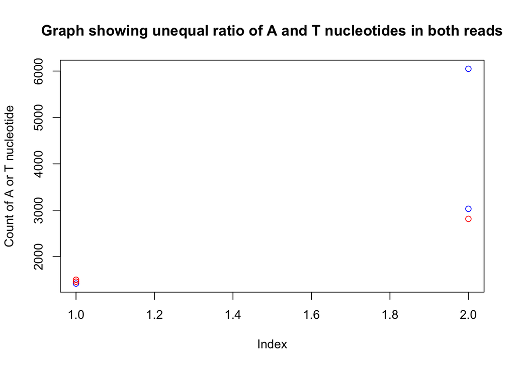

```r
r1fox17 <- c(1420, 6049)
r2fox17 <- c(6340, 3031)
r1ctrl24 <- c(1502, 1031)
r2ctrl24 <- c(1460, 2814)

s <- data.frame(r1fox17, r2fox17, r1ctrl24, r2ctrl24, row.names = c("polyA", "polyT"))
colnames(s) <- c("r1fox17", "r2fox17", "r1ctrl24", "r2ctrl24")

plot(s$r1fox17, col = "blue", ylab="Count of A or T nucleotide", main = "Graph showing unequal ratio of A and T nucleotides in both reads")
points(s$r2fox17, col = "blue")
points(s$r1ctrl24, col = "red")
points(s$r2ctrl24, col = "red")
```

To turn in your work for this assignment: Please upload your Talapas batch script/code, FastQC plots, answers to questions, and any additional plots/code to github.